[figure not shown]

# Your personalised newsletter

Welcome to your personalised newsletter for **June** . Here are insights and inspirations based on your recording from last month.

### A great find!

Your visit in June to the highest recording priority area was your visit to Clipstone, Newark and Sherwood and recorded 7 species. One of the species you recorded was *Aphantopus hyperantus.*

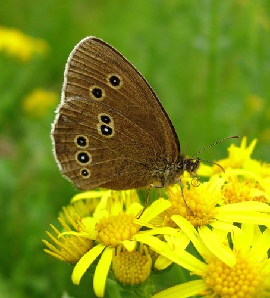

*(c) Laurence Livermore, some rights reserved (CC BY-NC)*

[Go to DECIDE](https://decide.ceh.ac.uk/opts/scoremap/map)

### Going the extra mile

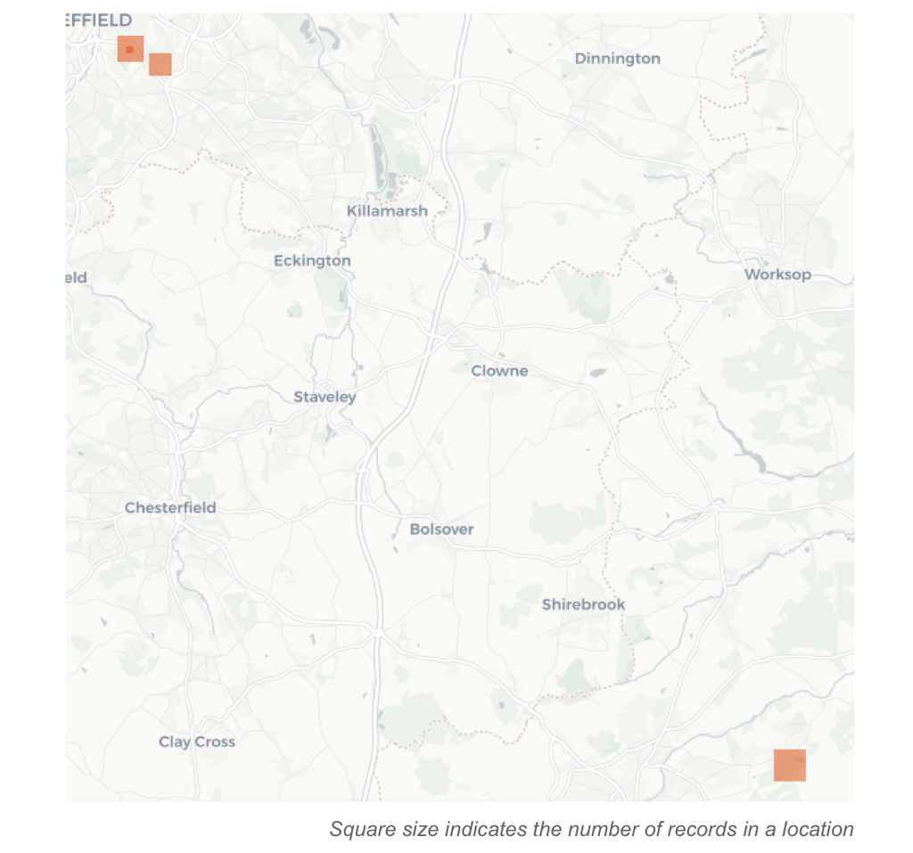

### Some inspiration?

Below are some high priority location suggestion, why not go to one of these next time you record?

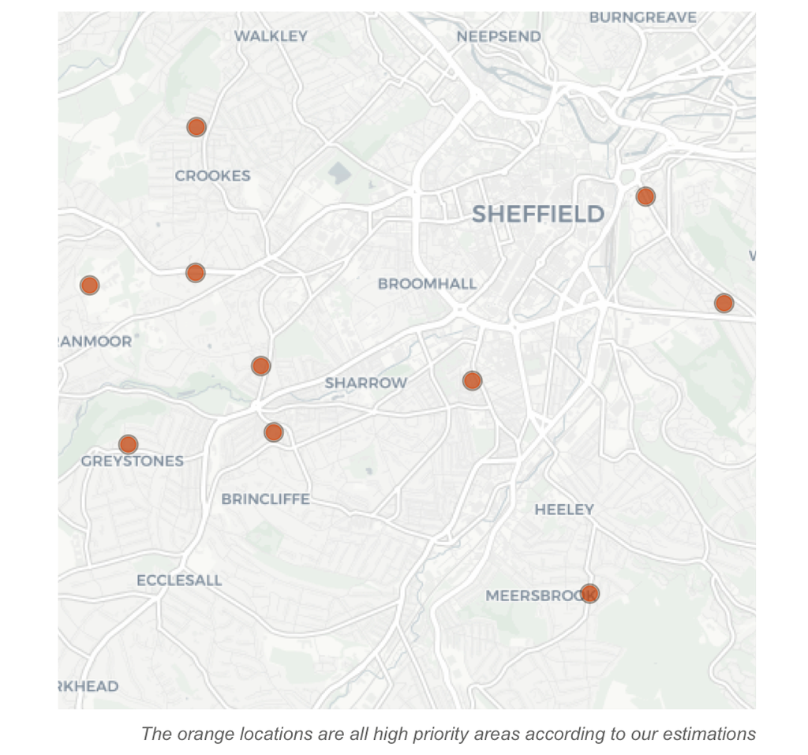

[Go to DECIDE and explore these suggestions?](https://decide.ceh.ac.uk/opts/scoremap/map)

### Community recording near you

The DECIDE comunity has been very active this month. See where your records fall within them:

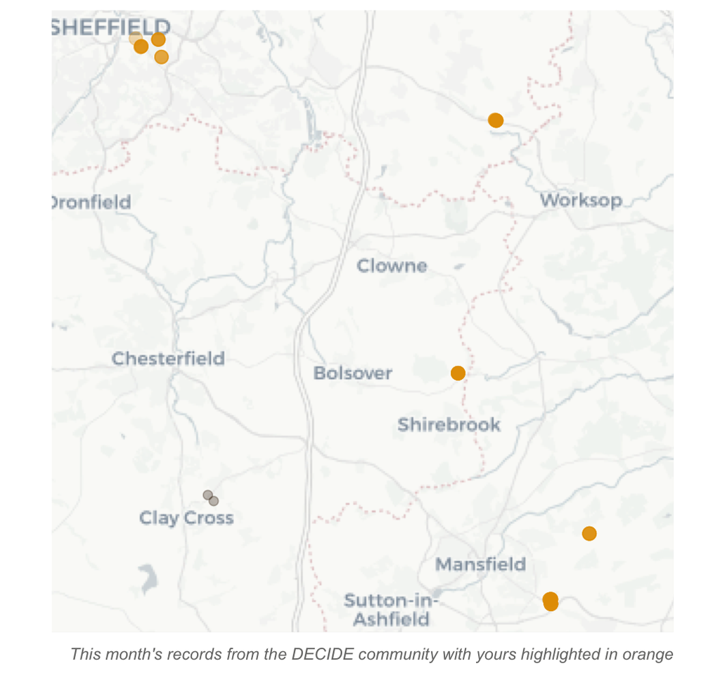

Why not find some gaps in your area using the DECIDE tool?

[Go to DECIDE](https://decide.ceh.ac.uk/opts/scoremap/map)

### How is your DECIDE score?

High DECIDE scores indicate records from high priority areas. See how your records from June add up

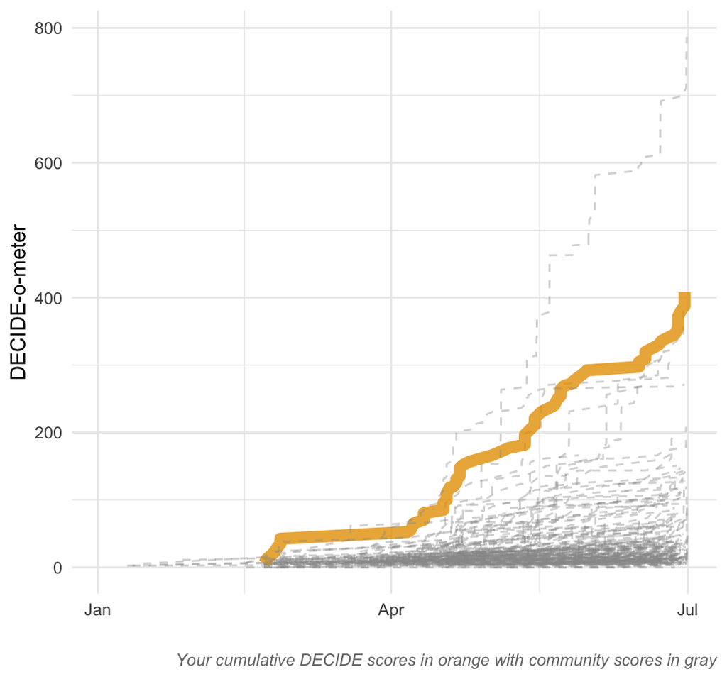

Why not find areas with high priority scores using the DECIDE tool?

[Go to DECIDE](https://decide.ceh.ac.uk/opts/scoremap/map)

Don't want to receive these emails any more? Unsubscribe from the DECIDE personalised newsletter